tmn2136-W4111-Spring-2026-002-HW2.ipynb

# Introduction

## Homework Overview

There is one version of the homework that both the programming and non-programming tracks complete.

There are 4 categories of question:

1. Short answer questions testing general knowledge and the ability to reason about the course material.
2. Entity-Relationship modeling questions testing the ability to define an ER model from a text/written description of a problem and to translate an ER model into SQL.
3. Relational algebra questions testing the ability to use the relational algebra.
4. SQL questing testing the ability to use SQL to produce data results from descriptions of the desired output.

## Submission Instructions

The homework is due at 11:59 PM on Sunday, 08-March-2026.

Please see [Ed discussion](https://edstem.org/us/courses/94820/discussion/7712431) for detailed submission instructions and for clarifications and answering questions.

# Part 1 $-$ Setup

## iPython-SQL

```python
%load_ext sql
```

```
The sql extension is already loaded. To reload it, use:
  %reload_ext sql
```

Set the proper root user ID and password for MySQL in the python cell below.

```python
mysql_root_user = 'root'
mysql_root_password = '9378456Nt!123'

mysql_url = f"mysql+pymysql://{mysql_root_user}:{mysql_root_password}@localhost"
```

```python
mysql_url
```

```
'mysql+pymysql://root:9378456Nt!123@localhost'
```

```python
%sql $mysql_url
```

```python
%config SqlMagic.style = '_DEPRECATED_DEFAULT'
```

```python
%sql select * from db_book.student where dept_name="Comp. Sci."
```

```
 * mysql+pymysql://root:***@localhost
4 rows affected.
```

| ID | name | dept_name | tot_cred |
| --- | --- | --- | --- |
| 00128 | Zhang | Comp. Sci. | 102 |
| 12345 | Shankar | Comp. Sci. | 32 |
| 54321 | Williams | Comp. Sci. | 54 |
| 76543 | Brown | Comp. Sci. | 58 |

## SQL Alchemy

```python
from sqlalchemy import create_engine, text
```

```python
engine = create_engine(mysql_url)
```

```python
# Raw SQL query
sql = text("SELECT * FROM db_book.student WHERE dept_name = :dept")

# Execute query
with engine.connect() as connection:
    result = connection.execute(sql, {"dept": "Comp. Sci."})

    for row in result:
        print(row)
```

```
('00128', 'Zhang', 'Comp. Sci.', Decimal('102'))
('12345', 'Shankar', 'Comp. Sci.', Decimal('32'))
('54321', 'Williams', 'Comp. Sci.', Decimal('54'))
('76543', 'Brown', 'Comp. Sci.', Decimal('58'))
```

## Pandas

```python
import pandas
```

```python
result = pandas.read_sql(con=engine, sql="select * from db_book.student where dept_name='Comp. Sci.'")
```

```python
result
```

|  | ID | name | dept_name | tot_cred |
| --- | --- | --- | --- | --- |
| 0 | 00128 | Zhang | Comp. Sci. | 102.0 |
| 1 | 12345 | Shankar | Comp. Sci. | 32.0 |
| 2 | 54321 | Williams | Comp. Sci. | 54.0 |
| 3 | 76543 | Brown | Comp. Sci. | 58.0 |

## PyMySQL

```python
import pymysql
```

```python
conn = pymysql.connect(
    host="localhost",
    user=mysql_root_user,
    password=mysql_root_password,
    cursorclass=pymysql.cursors.DictCursor,
    autocommit=True
)
```

```python
cursor = conn.cursor()
```

```python
result = cursor.execute("select * from db_book.student where dept_name='Comp. Sci.'")
result = cursor.fetchall()
```

```python
result
```

```
[{'ID': '00128',
  'name': 'Zhang',
  'dept_name': 'Comp. Sci.',
  'tot_cred': Decimal('102')},
 {'ID': '12345',
  'name': 'Shankar',
  'dept_name': 'Comp. Sci.',
  'tot_cred': Decimal('32')},
 {'ID': '54321',
  'name': 'Williams',
  'dept_name': 'Comp. Sci.',
  'tot_cred': Decimal('54')},
 {'ID': '76543',
  'name': 'Brown',
  'dept_name': 'Comp. Sci.',
  'tot_cred': Decimal('58')}]
```

# Written Questions

The written questions test general knowledge of the material presented in lectures and in the slides from the recommended textbook.

Your answers should be short and simple, and typically less than 5 sentences.

We will deduct points for answers that are rambling, too long, throwing out ideas and hoping something is correct, etc.

## Q1

#### Question

Using the approach/notation from lecture 3, slides 5 and 6 (also labelled 6.5, 6.6), what is the *relationship set* for the following diagrams?

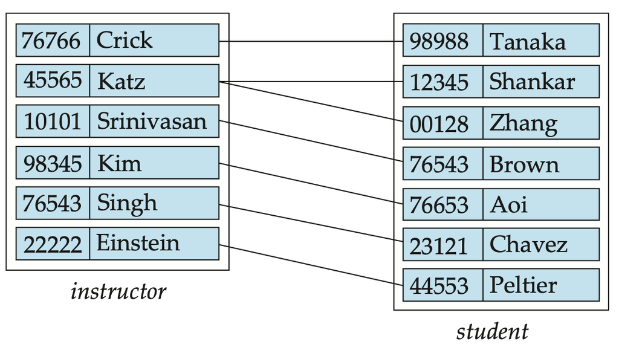

#### Answer

{ (98988,76766), (12345,45565), (00128,45565), (76543,10101), (76653,98345), (23121,76543), (44553,22222) }

## Q2

#### Question

What are the two primary reasons for using an *associative entity* to implement a relationship between two entity sets?

#### Answer

1. If the relationship between two entity sets is many-to-many, then we must use an associative entity
2. If the relationship itself has attributes, ex. a person may have multiples accounts with multiple banks, this relationship is M:M. However, each account has (at least) an account number, bank ID, balance. The account number and bank ID are PK/FK but balance is an attribute unique to this pair. It must be stored in an associative entity.

## Q3

#### Question

Briefly explain the concept of a *weak entity.*

#### Answer

A weak entity is an entity that cannot be uniquely identified by its attributes alone and requires a partial key and foreign key from an identifying (owner) entity to be uniquely identified. Often takes the form of

PRIMARY KEY (course_id, sec_id, semester, year), FOREIGN KEY (course_id) REFERENCES course(course_id)

## Extra question

#### Answer

Consider two the union of two relations in the relational algebra, e.g. r U s. What two criteria are necessary for the union to be possible?

1. The arity of the relations must be the same, i.e. they must have the same number of attributes
2. The respective domains of each attribute must be the same

## Q4

#### Question

What are the 4 types of integrity constraint on a single relation/table in SQL?

#### Answer

1. Not null
2. Unique
3. Primary key
4. Check

## Q5

#### Question

What is the key difference between a *unique* constraint and a *primary key* constraint?

#### Answer

Both offer to uniquely identify a tuple (row) but a primary key is a minimal candidate key. That means that a unique constraint is a candidate key that can be null, whereas a primary key cannot be null. Lastly, unique allows for multiple null attributes (null <> null) whereas primary key constraints prohibit it entirely. Thus, the primary key constraint implicitly enforces the not null constraint

## Q6

#### Question

Briefly explain the concepts of *disjoint/overlapping* and *total/partial* with respect to inheritance.

#### Answer

1. Disjoint: an entity can belong to only one subtype ex. a vehicle can be a subtype of truck or car but not both
2. Overlapping: an entity can belong to more than one subtype ex. a person could be an employee and a student at the same time
3. Total: Every entity in the supertype must appear in at least one subtype.
4. Partial: An entity in the supertype may or may not belong to any subtype.

Together, we can have 4 constraint pairs that each deal with how an entity belongs to subtypes.

Disjoint & partial: an entity can belong to 1 or 0 subtypes

Disjoint & total: an entity can belong to exactly 1 subtype

Overlapping & partial: an entity can belong 0 or many subtypes

Overlapping & total: an entity can belong to at least 1 (or more) subtypes

## Q7

#### Question

Briefly explain the following concepts:

1. Natural join
2. Theta join
3. Inner join
4. Outer join

#### Answer

1. Natural join: joins two or more relations on identically named attributes with same attribute domain and values, can cause issues when attributes have same names but diff meanings
2. Theta join: joins relations on a predicate theta. Avoids the issue of natural join joining on unrelated attributes
3. Inner join: joins two relations and returns only the rows that have matching values in both relations on the join condition. Non-matching rows are discarded entirely. This is the default JOIN behavior in SQL. Sort of like full outer join with no null values
4. Outer join: can be obtained by composing a left outer join with a right outer join (or vice versa) and preserves all rows from one or both relations, filling in NULL for missing values where there is no match.

Comes in three varieties: left outer join: keeps all rows from the left relation, right outer join (similar to left outer join), and full outer join (keeps all rows from both relations)

## Q8

#### Question

Assume that a database implementation does not support `FULL OUTER JOIN`. How is it possible to implement an equivalent query using other operations?

#### Answer

$$r ⟕ s \cup r ⟖ s = r ⟗ s$$

## Q9

#### Question

What are the 3 types of Join conditions?

#### Answer

1. Natural join: Joins on all identically named attributes automatically and doesn't require an explicit condition
2. Join on: joins using an explicit predicate, recall theta join
3. Join using: similar to natural join but users explicitly list which attributes to join on, avoids joining on unintended columns

## Q10

#### Question

Briefly explain **Codd's 4th Rule: Active Online Catalog:** *The structure description of the entire database must be stored in an online catalog, known as data dictionary, which can be accessed by authorized users. Users can use the same query language to access the catalog which they use to access the database itself.*

What is the name of the schema/database for the catalog in MySQL?

#### Answer

The rule is saying that the DB should store its own structure that users can access in the same way they typically interact with the DB. This means that there must exist a query users can make that describes the schema of the DB. This query should be able to reflect real time changes as users make changes.

In MySQL, this is called the information_schema and it contains information about the server such as tables, attributes, constraints and privileges.

# Entity Relationship Modelling

## ER1

#### Question

Consider the following description of a datamodel.

A company sells products to customers. The operational database contains the following tables.

Your task is to draw a **logical ER diagram using Crow’s Foot notation** based solely on the description below.

From the description, you must determine:

- Primary keys
- Composite keys
- Foreign keys
- Cardinalities
- Optional vs. mandatory participation
- Whether any entity is associative

Customer

Each **Customer** represents a company that purchases products.

Attributes

- customerNumber — unique identifier for a customer
- customerName
- contactLastName
- contactFirstName
- phone
- addressLine1
- addressLine2
- city
- state
- postalCode
- country
- creditLimit

Business Rules

- Each customer has a unique `customerNumber`.
- A customer may place zero, one, or many orders.
- A customer may make zero, one, or many payments.

Orders

Each **Order** represents a purchase transaction placed by a customer.

Attributes

- orderNumber — unique identifier for an order
- orderDate
- requiredDate
- shippedDate
- status
- comments

Business Rules

- Each order has a unique `orderNumber`.
- Each order is placed by exactly one customer.
- An order must contain at least one product.
- An order may contain many products.

OrderDetails

The **OrderDetails** table represents the individual line items of an order.

Attributes

- orderNumber
- productCode
- quantityOrdered
- priceEach
- orderLineNumber

Business Rules

- Each row represents one product appearing on one order.
- The combination of `orderNumber` and `productCode` uniquely identifies a line item.
- Each line item belongs to exactly one order.
- Each line item references exactly one product.

Products

Each **Product** represents an item available for sale.

Attributes

- productCode — unique identifier for a product
- productName
- productLine
- productScale
- productVendor
- productDescription
- quantityInStock
- buyPrice
- MSRP

Business Rules

- Each product has a unique `productCode`.
- A product may appear in zero, one, or many order line items.

Payments

Each **Payment** represents a payment made by a customer.

Attributes

- customerNumber
- checkNumber
- paymentDate
- amount

Business Rules

- Each payment is made by exactly one customer.
- A customer may make multiple payments.
- The combination of `customerNumber` and `checkNumber` uniquely identifies a payment.

Deliverable

Draw a **Crow’s Foot ER diagram** that includes:

- All entities
- All attributes
- Primary keys (clearly marked)
- Composite keys (clearly marked)
- All relationships and foreign keys
- Cardinalities
- Optional vs. mandatory participation

Do not include implementation details such as data types.

Using Crow's Foot Notation and Lucidchart or an equivalent tool, draw a **logical datamodel** for the scenario. Replace the image below with a screen capture of your diagram.

You may have to define additional attributes or entity types to implement your solution.

You may add notes to the diagrams to document any assumptions, explain concepts your could not fully express in Crow's Foot Notation, etc.

**NOTE:** The diagram below is a conceptual model. The question is asking you to define a logical model.

#### Answer

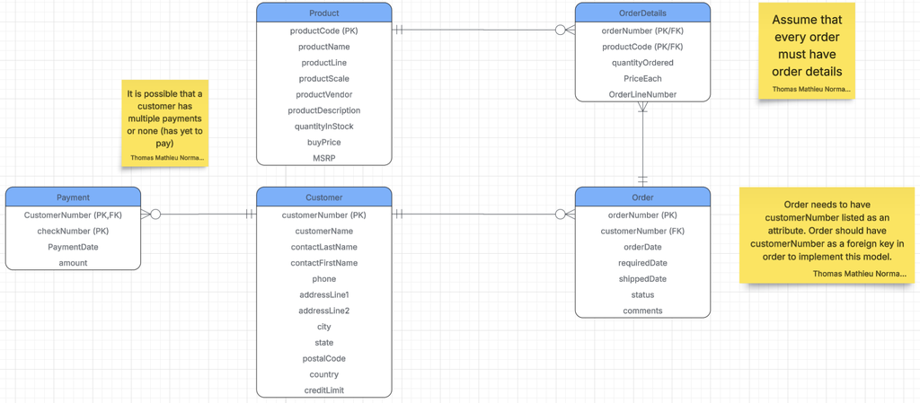

**Logical Model**

## ER2

#### Question

You are to translate/write DDL to create an SQL database implementing the following diagram. Unless otherwise specified, you can assume that all columns are `VARCHAR(64).`

The model has the additional constraints:

1. All `email` columns are `unique` within the table.
2. `School.school_code` is always exactly 4 characters.
3. `Department.department_code` is always exactly 4 characters.
4. `CUID` is `unique` and `not null`.
5. `Course.faculty_code` and `Section.course_code` are a single characters and the allowed values are "C", "B", "E" and "W".
6. `course_no` is always exactly 4 characters and only the digits "0", "1", ..., "9" are allowed characters.
7. The allowed values for `Section.semester` are `1`, `2` and `3`.
8. `StudentSection.role` can have the values `Enrolled`, `Waitlist`, `TA`.

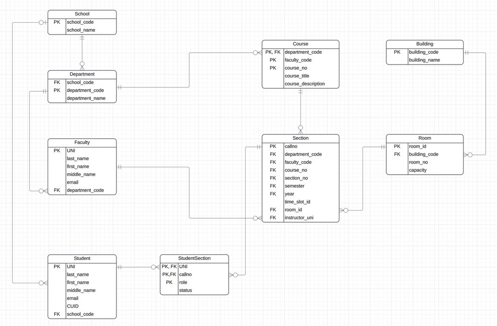

**Logical Model**

#### Answer

```python
%%sql

drop database if  exists w4111_hw2;
create database w4111_hw2;
USE w4111_hw2;

CREATE TABLE school(
    school_code char(4) PRIMARY KEY,
    school_name varchar(64)
);

CREATE TABLE student(
    UNI VARCHAR(64) PRIMARY KEY,
    last_name VARCHAR(64),
    first_name VARCHAR(64),
    middle_name VARCHAR(64),
    email VARCHAR(64),
    school_code char(4),
    CUID VARCHAR(64) not NULL,
    UNIQUE(email),
    UNIQUE(CUID),
    FOREIGN KEY (school_code) REFERENCES school(school_code)
);

CREATE TABLE Department(
  school_code char(4),
  department_code char(4) PRIMARY KEY,
  department_name VARCHAR(64),
  FOREIGN KEY (school_code) REFERENCES school(school_code)
);

CREATE TABLE Faculty(
  UNI VARCHAR(64) PRIMARY KEY,
  last_name VARCHAR(64),
  first_name VARCHAR(64),
  middle_name VARCHAR(64),
  email VARCHAR(64),
  department_code char(4),
  FOREIGN KEY (department_code) REFERENCES Department(department_code),
  UNIQUE(email)
);

CREATE TABLE Building(
  building_code VARCHAR(64) PRIMARY KEY,
  building_name VARCHAR(64)
);

CREATE TABLE Room(
  room_id VARCHAR(64) PRIMARY KEY,
  building_code VARCHAR(64),
  room_no VARCHAR(64),
  capacity VARCHAR(64),
  FOREIGN KEY (building_code) REFERENCES Building(building_code)
);

CREATE TABLE Course(
  department_code char(4),
  faculty_code CHAR(1),
  course_no CHAR(4),
  course_title VARCHAR(64),
  course_description VARCHAR(64),

  PRIMARY KEY (department_code, faculty_code, course_no),
  FOREIGN KEY (department_code) REFERENCES Department(department_code),
  CHECK (faculty_code IN ('C', 'B', 'E', 'W')),
  CHECK (
      SUBSTRING(course_no, 1, 1) BETWEEN '0' AND '9' AND
      SUBSTRING(course_no, 2, 1) BETWEEN '0' AND '9' AND
      SUBSTRING(course_no, 3, 1) BETWEEN '0' AND '9' AND
      SUBSTRING(course_no, 4, 1) BETWEEN '0' AND '9'
  )
);


CREATE TABLE section(
  callno VARCHAR(64) PRIMARY KEY,
  department_code CHAR(4),
  faculty_code CHAR(1),
  course_no char(4),
  section_no VARCHAR(64),
  semester CHAR(1),
  year VARCHAR(64),
  time_slot_id VARCHAR(64),
  room_id VARCHAR(64),
  instructor_uni VARCHAR(64),

  CHECK (
    SUBSTRING(course_no, 1, 1) BETWEEN '0' AND '9' AND
    SUBSTRING(course_no, 2, 1) BETWEEN '0' AND '9' AND
    SUBSTRING(course_no, 3, 1) BETWEEN '0' AND '9' AND
    SUBSTRING(course_no, 4, 1) BETWEEN '0' AND '9'
),
  CHECK(
    faculty_code in ('C','B','E','W')
  ),
  CHECK(
    semester in ('1','2','3')
  ),

  FOREIGN KEY (department_code,faculty_code,course_no) REFERENCES Course(department_code, faculty_code,course_no),
  FOREIGN KEY (instructor_uni) REFERENCES Faculty(UNI),
  FOREIGN KEY (room_id) REFERENCES Room(room_id)
);

CREATE TABLE StudentSection(
  UNI VARCHAR(64),
  callno VARCHAR(64) ,
  role VARCHAR(64) ,
  status VARCHAR(64),
  PRIMARY KEY (UNI, callno,role),
  FOREIGN KEY (UNI) REFERENCES student(UNI),
  FOREIGN KEY (callno) REFERENCES section(callno),
  CHECK (role in ('Enrolled', 'Waitlist', 'TA'))
);
```

```
 * mysql+pymysql://root:***@localhost
9 rows affected.
1 rows affected.
0 rows affected.
0 rows affected.
0 rows affected.
0 rows affected.
0 rows affected.
0 rows affected.
0 rows affected.
0 rows affected.
0 rows affected.
0 rows affected.
```

```
[]
```

# Relational Algebra Questions

Using the [RelaX relational calculator](https://dbis-uibk.github.io/relax/calc/gist/4f7866c17624ca9dfa85ed2482078be8) and the sample data that comes with the recommended textbook for the following questions.

You answer will be a text copy/paste of your query and a screen capture/snip of the execution of the query.

## R1

#### Question

Write an algebra expression that computes a relation of the form `(ID, name)` that includes the `ID` and `name` of `instructors` that do not advise any students. You will use the relations `instructor` and `advisor`. My result looks like

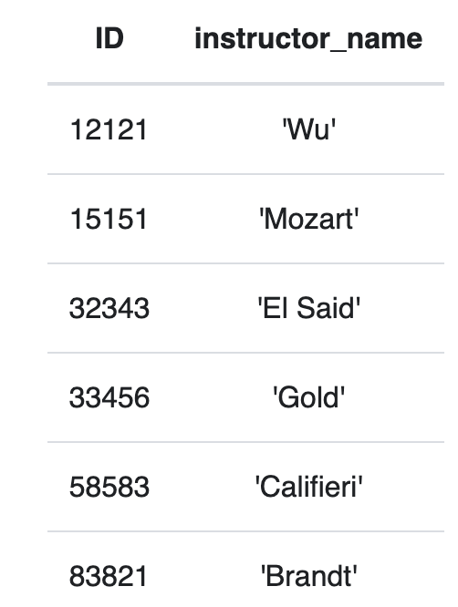

The answer area below contains an example of the result format but for a different query.

#### Answer

##### Execution Screen Capture

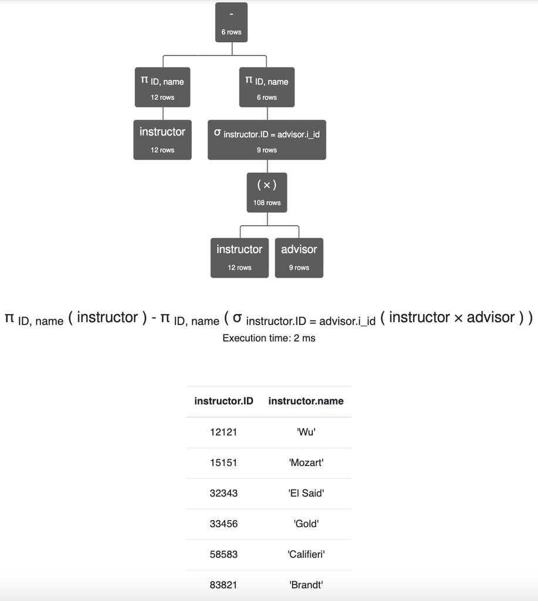

**R1 Answer**

## R2

#### Question

Write a relational algebra expression that produces a table of for the `(ID, name, course_id, title, credits)` that contains the `ID` and `name` of `instructors` and the `course_id, title` and `credits` for the `courses` they teach. Your result should only contain faculty in the `'Comp. Sci.` department. Your expression will use the relations `instructor`, `teaches` and `course`.

My answer looks like

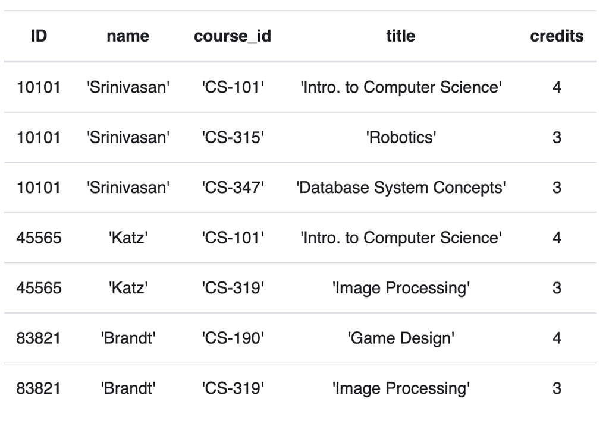

The answer area below contains an example of the result format but for a different query.

#### Answer

##### Relational Algebra Statement

`π instructor.ID, instructor.name, course.course_id, course.title,course.credits(σ instructor.dept_name='Comp. Sci.'(` `(instructor ⨝ instructor.ID = teaches.ID teaches) ⨝ teaches.course_id = course.course_id course))`

##### Execution Screen Capture

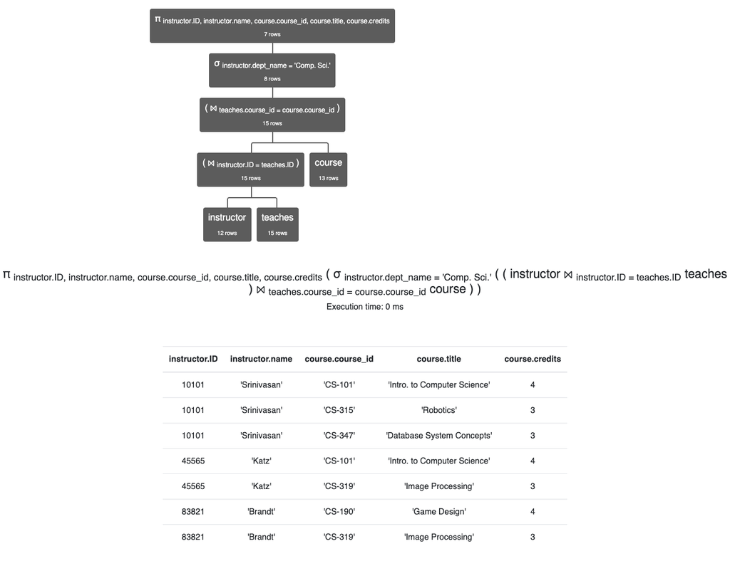

**R2 Answer**

## R3

#### Question

Write a relational algebra expression that computes the courses offered in both the Fall 2009 and Spring 2010. You use the `sections` relation for the expression. There is only one course, `'CS-101'` that is offered both in Fall 2009 and Spring 2010.

The answer area below contains an example of the result format but for a different query.

#### Answer

##### Relational Algebra Statement

`π course.course_id (σ section.semester = 'Fall' ∧ section.year = 2009(course ⨝ course.course_id = section.course_id section))` `∩` `π course.course_id (σ section.semester = 'Spring' ∧ section.year = 2010(course ⨝ course.course_id = section.course_id section))`

##### Execution Screen Capture

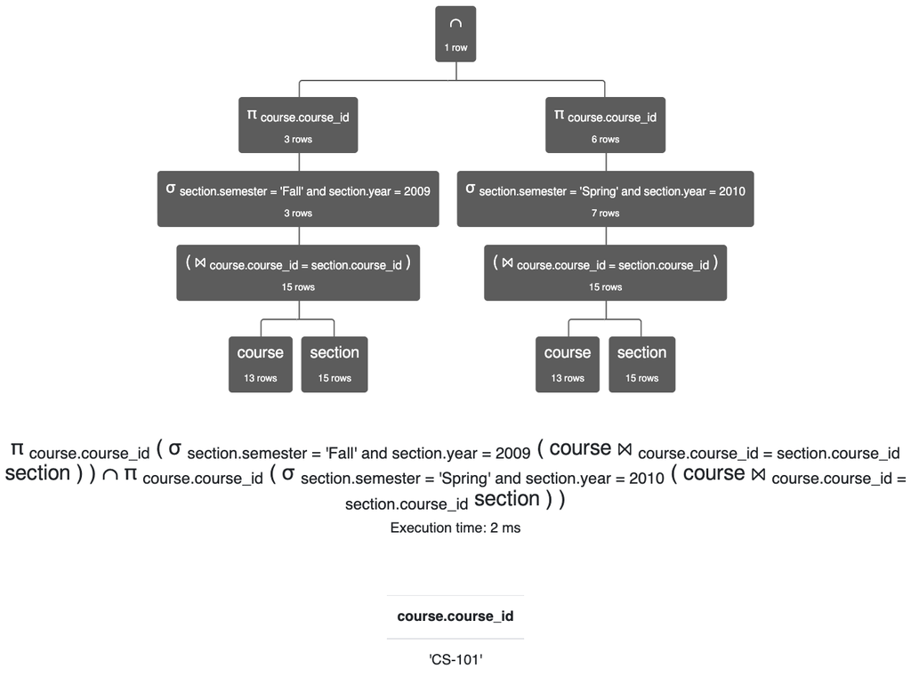

**R3 Answer**

# SQL

## S1

#### Question

Write and execute the SQL query that is equivalent to the relational algebra expression for question R1.

`π ID,name(instructor) - π ID,name(σ instructor.ID = advisor.i_id (instructor ⨯ advisor))`

#### Answer

```python
%%sql
use db_book;
SELECT ID,name
FROM instructor
EXCEPT
    SELECT ID,name
    FROM instructor
    JOIN advisor
    ON instructor.ID = advisor.i_id
;
```

```
 * mysql+pymysql://root:***@localhost
0 rows affected.
6 rows affected.
```

| ID | name |
| --- | --- |
| 12121 | Wu |
| 15151 | Mozart |
| 32343 | El Said |
| 33456 | Gold |
| 58583 | Califieri |
| 83821 | Brandt |

## S2

#### Question

Write and execute the SQL query that is equivalent to the relational algebra expression for question R2.

`π instructor.ID, instructor.name, course.course_id, course.title,course.credits(σ instructor.dept_name='Comp. Sci.'(` `(instructor ⨝ instructor.ID = teaches.ID teaches) ⨝ teaches.course_id = course.course_id course))`

#### Answer

```python
%%sql
SELECT DISTINCT instructor.ID, instructor.name, course.course_id, course.title,course.credits
FROM instructor
JOIN teaches
    ON instructor.ID = teaches.ID
JOIN course
    ON teaches.course_id = course.course_id
WHERE
    instructor.dept_name = 'Comp. Sci.'
;
```

```
 * mysql+pymysql://root:***@localhost
7 rows affected.
```

| ID | name | course_id | title | credits |
| --- | --- | --- | --- | --- |
| 10101 | Srinivasan | CS-101 | Intro. to Computer Science | 4 |
| 10101 | Srinivasan | CS-315 | Robotics | 3 |
| 10101 | Srinivasan | CS-347 | Database System Concepts | 3 |
| 45565 | Katz | CS-101 | Intro. to Computer Science | 4 |
| 45565 | Katz | CS-319 | Image Processing | 3 |
| 83821 | Brandt | CS-190 | Game Design | 4 |
| 83821 | Brandt | CS-319 | Image Processing | 3 |

## S3

#### Question

Write and execute the SQL query that is equivalent to the relational algebra expression for question R3.

**NOTE:**

1. You need to change the semesters to Fall 2017 and Spring 2018 because the data is different.
2. MySQL does not support `INTERSECT`. So, you will have to choose a different approach to performing the "intersection."

`π course.course_id (σ section.semester = 'Fall' ∧ section.year = 2009(course ⨝ course.course_id = section.course_id section))` `∩` `π course.course_id (σ section.semester = 'Spring' ∧ section.year = 2010(course ⨝ course.course_id = section.course_id section))`

#### Answer

```python
%%sql
SELECT DISTINCT section.course_id
FROM section
WHERE section.year = 2017 AND section.semester = 'Fall'
AND section.course_id IN (
    SELECT section.course_id
    FROM section
    WHERE section.year = 2018 AND section.semester = 'Spring'
);
```

```
 * mysql+pymysql://root:***@localhost
1 rows affected.
```

| course_id |
| --- |
| CS-101 |

## S4

#### Question

Without using any kind of JOIN, for the sample dataset, write a SQL query that produces a result of the form `(student_name, instructor_name)` that contains the name of a student and the student's advisor. Your query will use the tables `student, advisor` and `instructor`. Your query should only contain results for `instructors` in the `dept_name` `"Comp. Sci."`.

For reference my query produces

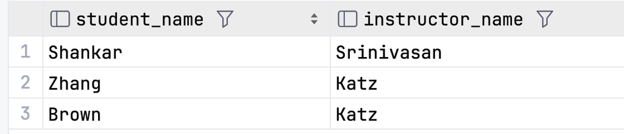

#### Answer

```python
%%sql
SELECT student.name student_name, instructor.name instructor_name
FROM student,advisor, instructor
WHERE student.ID = advisor.s_id AND advisor.i_id = instructor.ID AND instructor.dept_name = 'Comp. Sci.'
;
```

```
 * mysql+pymysql://root:***@localhost
3 rows affected.
```

| student_name | instructor_name |
| --- | --- |
| Shankar | Srinivasan |
| Zhang | Katz |
| Brown | Katz |

## S5

#### Question

Using the "online metadata catalog" for MySQL, write a query that produces a table of the form `(table_schema, table_name, column_name, ordinal_position, column_default, is_nullable, data_type)` for columns in the table `db_book.student`. For reference, my answer looks like

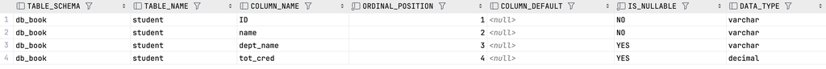

#### Answer

```python
%%sql

SELECT table_schema, table_name, column_name, ordinal_position, column_default, is_nullable, data_type
FROM information_schema.columns
WHERE table_schema = 'db_book'
AND table_name = 'student'
order by ordinal_position;
```

```
 * mysql+pymysql://root:***@localhost
4 rows affected.
```

| TABLE_SCHEMA | TABLE_NAME | COLUMN_NAME | ORDINAL_POSITION | COLUMN_DEFAULT | IS_NULLABLE | DATA_TYPE |
| --- | --- | --- | --- | --- | --- | --- |
| db_book | student | ID | 1 | None | NO | varchar |
| db_book | student | name | 2 | None | NO | varchar |
| db_book | student | dept_name | 3 | None | YES | varchar |
| db_book | student | tot_cred | 4 | None | YES | decimal |

## Create PDF

1. Use the `File -> Save and Export Notebook as -> HTML` option to save your notebook as an HTML file.
2. Copy the created HTML file to the same directory as the notebook and images you created.
3. Open the HTML file in a browser.
4. Using the *browser's* `File -> Print` option print the HTML file to a PDF. This is your submission format.
5. Follow the submission instructions on Ed Discussion to submit your file to GradeScope.

```python
! jupyter nbconvert *.ipynb --to html --embed-images
```

```
[NbConvertApp] Converting notebook dff9-W4111-Spring-2026-HW2-v2.ipynb to html
[NbConvertApp] WARNING | Alternative text is missing on 10 image(s).
[NbConvertApp] Writing 2975691 bytes to dff9-W4111-Spring-2026-HW2-v2.html
```